# Association of Statin Use with Sarcopenia in Adults Under 60: A Cross-Sectional Study

BMIN503/EPID600 Final Project

Author

Lin-Chieh Meng

## 1 Overview

This project is a cross-sectional study using data from the CDC’s National Health and Nutrition Examination Survey (NHANES) 2017-2018 to assess the association between statin use and the risk of sarcopenia in adults under 60 years of age.

To complete this project, I consulted with Dr. John Holmes, a Professor of Medical Informatics in Epidemiology, and Dr. Charles Leonard, an Associate Professor of Epidemiology. Dr. Holmes emphasized the importance of applying weights in the NHANES analysis to ensure that the results accurately represent the general population. Dr. Leonard advised me on handling missing data carefully and recommended using imputation methods for more robust analysis.

The objectives of this study are to: 1) explore the characteristics of individuals under 60 with sarcopenia, 2) examine the characteristics of individuals under 60 using statins, and 3) evaluate whether statin use impacts muscle health in younger adults. The findings from this study could enhance our understanding of poor muscle health in younger individuals. Additionally, these results could inform clinical decision-making regarding hyperlipidemia treatment and guide the selection of therapeutic options for cardiovascular disease prevention in younger adults.

Please find my Github Repository for the final project [here](https://github.com/linchiehmeng/BMIN503_Final_Project).

## 2 Introduction

Statins, widely prescribed as first-line lipid-lowering agents for both primary and secondary prevention of atherosclerotic cardiovascular disease (1), have seen increasing use, with a prevalence ranging from 15.4% to 27.9% in recent years (2). Sarcopenia, characterized by significant declines in muscle mass, strength, and performance (3), affects both younger and older populations, leading to musculoskeletal impairment and limitations in physical activity (3). Emerging evidence suggests that statins may contribute to muscle dysfunction through mechanisms involving inflammation, apoptosis, and the regulation of myostatin (4), which are associated with muscle-related adverse events (5). Given the critical role of muscle health in maintaining mobility, concerns have been raised about the potential impact of statins on muscle health, including the development of sarcopenia.

Previous research has shown that statin use among older populations may increase the risk of developing sarcopenia (6). However, few studies have focused on whether this association also exists in younger individuals, or on the characteristics of muscle health within this population. With modern dietary habits and lifestyle changes, the incidence of hyperlipidemia (7)—and consequently, cardiovascular disease (8,9)—as well as poor muscle health related to sarcopenia (10), has begun to affect younger populations at higher rates. As the first-line pharmacological treatment for hyperlipidemia, statins play a crucial role in disease management. Therefore, it is important to understand whether statin use may adversely impact muscle health in younger adults and to provide insights that inform clinical decision-making for optimal treatment strategies.

Therefore, this project aims to explore the characteristics of individuals under 60 with sarcopenia, to examine the characteristics of individuals under 60 using statins, and to evaluate whether statin use impacts muscle health in this younger population. This research requires a multidisciplinary approach, integrating public health, pharmacology, and muscle disease studies, while also leveraging data science, epidemiology, and statistical expertise to design the study and draw valid conclusions.

## 3 Methods

This cross-sectional study entailed a secondary analysis of data derived from the National Health and Nutrition Examination Survey (NHANES). NHANES was a cross-sectional survey conducted to assess the health and nutritional status of adults and children in the United States, providing robust external validity for extrapolating results to the broader U.S. population. The distinctiveness of NHANES lay in its integration of comprehensive interviews, physical examinations, and evaluations of physical activity and fitness. Since its inception in 1971, the survey had been conducted by the Centers for Disease Control and Prevention (CDC), with full documentation of its procedures and contents publicly available at https://wwwn.cdc.gov/nchs/nhanes/Default.aspx (accessed November 2024). This analysis specifically focused on participants from the 2017-2018 survey cycle.

The study subjects included participants aged 20-59 years who had completed an interview screening, a full examination at a standardized mobile examination center, and body composition measurements using dual-energy X-ray absorptiometry (DEXA).

The study identified the exposure as self-reported statin use. The outcome variable was sarcopenia, defined as appendicular lean mass in the lowest 20% stratified by age groups, according to definitions from previous studies. Several covariates were considered as confounders and were included in the adjustment model: gender, age, ethnicity, marital status, body mass index, smoking status, alcohol consumption, income status, nutritional status, physical activity level, general health condition, and comorbidities (i.e., hyperlipidemia, diabetes, hypertension, cardiovascular health status, chronic kidney disease, anxiety, depression, and history of fractures).

This study conducted a descriptive analysis of the characteristics of participants with and without sarcopenia. Multivariate logistic regression models, adjusted for the potential confounders mentioned above, were used to examine the association between statin use and sarcopenia. Both crude and adjusted odds ratios with 95% confidence intervals were reported. Missing data were handled by an iterative algorithm similar to Multiple Imputation by Chained Equations, using a method that applied predictive mean matching with additive regression models and bootstrapping. For this analysis, a single imputation was performed. A two-tailed p-value of <0.05 was considered statistically significant. However, due to the cross-sectional design of the study, the ability to draw definitive conclusions regarding the causal relationship between statin use and sarcopenia was limited.

For the analysis, I first identified and loaded all the necessary libraries.

```r
library(nhanesA)
library(haven)
library(dplyr)
library(purrr)
library(boot)
library(Hmisc)
library(tableone)
library(labelled)
library(ggplot2)
library(survey)
library(forestplot)
```

I used the “nhanesA” package to access the 2017-2018 NHANES data (n=9254). Subsequently, I identified and extracted the variables required for the study, including the exposure, outcomes, and covariates.

```r
#Step 1 - Data preparation

#Select the necessary variables from NHANES data 2017-2018
#------------------------------Covariates------------------------------
#Demography
demo_data <- nhanes('DEMO_J', translate=FALSE) %>%
  rename(id = SEQN, gender= RIAGENDR, age = RIDAGEYR, race = RIDRETH3, education = DMDEDUC2, marital = DMDMARTL, income = INDHHIN2, exam_weight=WTMEC2YR) %>%
  select(id, gender, age, race, education, marital, income, exam_weight )

#Alcohol use
alq_data <- nhanes('ALQ_J', translate=FALSE) %>%
  rename(id = SEQN, alcohol = ALQ111) %>%
  select(id, alcohol)

#Blood pressure and cholesterol
bpq_data <- nhanes('BPQ_J', translate=FALSE) %>%
  rename(id = SEQN, HTN = BPQ020, lipid = BPQ080) %>%
  select(id, HTN, lipid)

#Cardiovascular health
cdq_data <- nhanes('CDQ_J', translate=FALSE) %>%
  rename(id = SEQN, cardio_health = CDQ001) %>%
  select(id, cardio_health)

#Diet behavior & nutrition
dbq_data <- nhanes('DBQ_J', translate=FALSE) %>%
  rename(id = SEQN, diet= DBQ700) %>%
  select(id, diet)

#Diabetes
diq_data <- nhanes('DIQ_J', translate=FALSE) %>%
  rename(id = SEQN, diabetes= DIQ010) %>%
  select(id, diabetes)

#Disability & anxious & depression
dlq_data <- nhanes('DLQ_J', translate=FALSE) %>%
  rename(id = SEQN, walk_dis= DLQ050, anxious = DLQ130, depression = DLQ170 ) %>%
  select(id, walk_dis, anxious, depression)

#Self-reported current health status
hsq_data <- nhanes('HSQ_J', translate=FALSE) %>%
  rename(id = SEQN, health= HSD010) %>%
  select(id, health)

#Kidney disease
kiq_data <- nhanes('KIQ_U_J', translate=FALSE) %>%
  rename(id = SEQN, CKD= KIQ022) %>%
  select(id, CKD)

#Osteoporosis
osq_data <- nhanes('OSQ_J', translate=FALSE) %>%
  rename(id = SEQN, fractured_hip= OSQ010A, fractured_wrist= OSQ010B , fractured_spine= OSQ010C) %>%
  select(id, fractured_hip, fractured_wrist, fractured_spine)

#Physical activity
paq_data <- nhanes('PAQ_J', translate=FALSE) %>%
  rename(id = SEQN, Physical= PAQ605 ) %>%
  select(id, Physical)

#Smoking
smq_data <- nhanes('SMQ_J', translate=FALSE) %>%
  rename(id = SEQN, Smoking= SMQ040) %>%
  select(id, Smoking)

#Height & Weight
whq_data <- nhanes('WHQ_J', translate=FALSE) %>%
  rename(id = SEQN, Height= WHD010, Weight = WHD020) %>%
  select(id, Height, Weight)

#---------------------------Exposure-------------------------------
#Statin use
rxq_data <- nhanes('RXQ_RX_J', translate=FALSE) %>%
  rename(id = SEQN, Drug= RXDDRUG) %>%
  select(id, Drug)

statin_users <- rxq_data  %>%
  filter(grepl("STATIN", Drug, ignore.case = TRUE)) %>%
  distinct(id, .keep_all = TRUE)
statin_users$statin_use <- 1
#---------------------------Outcome-------------------------------

#Appendicular muscle mass
dxx_data <-  nhanes('DXX_J', translate=FALSE) %>%
  rename(id = SEQN, left_arm= DXDLALE , left_leg = DXDLLLE,  right_arm = DXDRALE,  right_leg = DXDRLLE ) %>%
  select(id, left_arm, left_leg, right_arm, right_leg)

#---------------------Merge all data frames by id----------------------
data_list <- list(alq_data, bpq_data, cdq_data, dbq_data, demo_data, diq_data, dlq_data, dxx_data, hsq_data, kiq_data, osq_data, paq_data, statin_users, smq_data, whq_data)

merged_data <- reduce(data_list, full_join, by = "id")
```

I then cleaned the data by applying the inclusion and exclusion criteria. I identified all participants who took part in the NHANES screening during 2017-2018 and excluded those with missing outcome variables (i.e., those without DXA tests) (n=5540) and individuals under 20 years of age (n=1463). Since the NHANES 2017-2018 screening only conducted DXA tests for participants under 60 years old, my study population included individuals aged 20-59 (n=2251).

For outcome identification, I first calculated appendicular muscle mass by summing the weights from both arms and legs. Individuals with appendicular muscle mass in the lowest 20% within their age group and gender were classified as having sarcopenia, according to definitions from previous studies.

I further labeled each covariate based on clinical insights. For certain variables, I retained the missing data for subsequent imputation analysis.

```r
#Step 2 - Data cleaning

#Remove rows with missing values in any composite of the outcome variables
merged_data <- merged_data %>%
  filter(!is.na(left_arm) & !is.na(left_leg) & !is.na(right_arm) & !is.na(right_leg))

#Exclude those aged<20 years
merged_data <- merged_data[merged_data$age >= 20, ]

#Create age groups
merged_data <- merged_data %>%
  mutate(age_group = case_when(
    age >= 20 & age <= 29 ~ "1",
    age >= 30 & age <= 39 ~ "2",
    age >= 40 & age <= 49 ~ "3",
    age >= 50 & age <= 59 ~ "4",
  ))

#Defining the outcome: individuals with appendicular lean weight in the lowest 20% stratified by age groups and gender are considered to have sarcopenia, according to definitions from previous studies
merged_data <- merged_data %>%
  mutate(ALM = left_arm + left_leg + right_arm + right_leg) %>%
  group_by(age_group, gender) %>%
  mutate(
    sarcopenia = ifelse(ALM < quantile(ALM, 0.20, na.rm = TRUE), 1, 0)
  ) %>%
  ungroup()

#Set up the categories for each variable, categorizing missing values as missing for later imputation
overall_data <- merged_data %>%
  mutate(
    alcohol_n = ifelse(alcohol == 1, 1, ifelse(is.na(alcohol), NA, 0)),
    HTN_n = ifelse(HTN == 1, 1, ifelse(is.na(HTN), NA, 0)),
    lipid_n = ifelse(lipid == 1, 1, ifelse(is.na(lipid), NA, 0)),
    cardio_n = ifelse(!is.na(cardio_health) & cardio_health == 1, 1, 0),
    diet_n = ifelse(diet %in% c(4, 5, 7, 9), 0, ifelse(is.na(diet), NA, 1)),
    education_n = ifelse(education %in% c(3, 4, 5), 1, ifelse(is.na(education), NA, 0)),
    marital_n = ifelse(marital %in% c(1, 6), 1, ifelse(is.na(marital), NA, 0)),
    income = ifelse(income %in% c(77, 99), 0, income),
    diabetes_n = ifelse(diabetes == 1, 1, ifelse(is.na(diabetes), NA, 0)),
    walk_dis_n = ifelse(walk_dis == 1, 1, ifelse(is.na(walk_dis), NA, 0)),
    anxious_n = ifelse(!is.na(anxious) & anxious %in% c(1, 2, 3), 1, 0),
    depression_n = ifelse(!is.na(depression) & depression %in% c(1, 2, 3), 1, 0),
    health_n = ifelse(health %in% c(1, 2, 3), 1, ifelse(is.na(health), NA, 0)),
    CKD_n = ifelse(CKD == 1, 1, ifelse(is.na(CKD), NA, 0)),
    fractured_n = ifelse
    (!is.na(fractured_hip) & fractured_hip == 1 |
     !is.na(fractured_wrist) & fractured_wrist == 1 |
     !is.na(fractured_spine) & fractured_spine == 1, 1, 0),
    physical_n = ifelse(!is.na(Physical) & Physical == 1, 1, 0),
    statin_use = ifelse(is.na(statin_use), 0, statin_use),
    smoking_n = ifelse(Smoking %in% c(1, 2), 1, ifelse(is.na(Smoking), NA, 0)),
    BMI = ifelse(!is.na(Weight) & !is.na(Height),
                 Weight * 0.45359237 / (Height * 2.54 / 100)^2,
                 NA)
  ) %>%
  mutate(
    BMI = ifelse(is.na(BMI) | BMI < 10, mean(BMI, na.rm = TRUE), BMI),
    BMI = ifelse(is.na(BMI) | BMI >60, mean(BMI, na.rm = TRUE), BMI)
  )

#Drop variables not needed for the analysis
overall_data2 <- overall_data %>%
  select(-alcohol, -HTN, -lipid, -cardio_health, -diet, -education, -marital, -age, -diabetes, -walk_dis, -anxious, -depression, -left_arm, -left_leg, -right_arm, -right_leg, -health, -CKD, -fractured_hip, -fractured_wrist, -fractured_spine, -Physical, -Drug, -Smoking, -Height, -Weight, -ALM)
```

Missing data were handled using a method that applied predictive mean matching with additive regression models and bootstrapping. This process resulted in a final dataset with all variables prepared for analysis.

```r
#Step 3 - Imputation for the missing data and label the covariates
impute_data <- aregImpute(
  ~ income + alcohol_n + HTN_n + lipid_n + cardio_n + diet_n +
    education_n + marital_n + diabetes_n + walk_dis_n + health_n +
    CKD_n + smoking_n,
  data = overall_data2,
  n.impute = 1
)
```

```
Iteration 1
Iteration 2
Iteration 3
Iteration 4
```

```r
# Extract the imputed columns as a data frame
imputed_data <- impute.transcan(impute_data, imputation = 1, data = overall_data2, list.out = TRUE, pr = FALSE)
imputed_data <- as.data.frame(imputed_data)

# Combine the imputed data with non-imputed columns from the original dataset to obtain final dataset
final_data <- overall_data2 %>%
  select(-income, -alcohol_n, -HTN_n, -lipid_n, -cardio_n, -diet_n,
         -education_n, -marital_n, -diabetes_n, -walk_dis_n, -health_n,
         -CKD_n, -smoking_n) %>%
  bind_cols(imputed_data)

# Label the covariates
final_data$sarcopenia <- factor(final_data$sarcopenia, levels = c(0, 1), labels = c("Without Sarcopenia", "With Sarcopenia"))
final_data$gender <- factor(final_data$gender, levels = c(1, 2), labels = c("Male", "Female"))
final_data$race <- factor(final_data$race, levels = c(1, 2, 3, 4, 6, 7),
                          labels = c("Mexican American", "Other Hispanic", "Non-Hispanic White",
                                     "Non-Hispanic Black", "Non-Hispanic Asian", "Other Race"))
final_data$age_group <- factor(final_data$age_group, levels = c("1", "2", "3", "4"),
                               labels = c("20-29 years", "30-39 years", "40-49 years", "50-59 years"))
final_data$income <- factor(final_data$income, levels = 0:15,
                            labels = c("Refused to Answer", "$0 to $4,999", "$5,000 to $9,999",
                                       "$10,000 to $14,999", "$15,000 to $19,999",
                                       "$20,000 to $24,999", "$25,000 to $34,999",
                                       "$35,000 to $44,999", "$45,000 to $54,999",
                                       "$55,000 to $64,999", "$65,000 to $74,999",
                                       "Missing", "$20,000 and Over", "Under $20,000",
                                       "$75,000 to $99,999", "$100,000 and Over"))
final_data$statin_use <- factor(final_data$statin_use, levels = c(0, 1), labels = c("No Statin Use", "Statin Use"))
final_data$anxious_n <- factor(final_data$anxious_n, levels = c(0, 1), labels = c("No History of Anxiety", "History of Anxiety"))
final_data$depression_n <- factor(final_data$depression_n, levels = c(0, 1), labels = c("No History of Depression", "History of Depression"))
final_data$fractured_n <- factor(final_data$fractured_n, levels = c(0, 1), labels = c("No History of Fracture", "History of Fracture"))
final_data$physical_n <- factor(final_data$physical_n, levels = c(0, 1), labels = c("Low Physical Activity", "High Physical Activity"))
final_data$alcohol_n <- factor(final_data$alcohol_n, levels = c(0, 1), labels = c("No Alcohol Use", "Alcohol Use"))
final_data$HTN_n <- factor(final_data$HTN_n, levels = c(0, 1), labels = c("No Hypertension", "Hypertension"))
final_data$lipid_n <- factor(final_data$lipid_n, levels = c(0, 1), labels = c("No Hyperlipidemia", "Hyperlipidemia"))
final_data$education_n <- factor(final_data$education_n, levels = c(0, 1), labels = c("Low Education Level", "High Education Level"))
final_data$marital_n <- factor(final_data$marital_n, levels = c(0, 1), labels = c("Not Married or Cohabiting", "Married or Cohabiting"))
final_data$smoking_n <- factor(final_data$smoking_n, levels = c(0, 1), labels = c("Non-Smoker", "Smoker"))
final_data$diet_n <- factor(final_data$diet_n, levels = c(0, 1), labels = c("Unhealthy Diet", "Healthy Diet"))
final_data$health_n <- factor(final_data$health_n, levels = c(0, 1), labels = c("Self-Perceived Poor Health", "Self-Perceived Good Health"))
final_data$cardio_n <- factor(final_data$cardio_n, levels = c(0, 1), labels = c("No Cardiovascular Disease", "Cardiovascular Disease"))
final_data$diabetes_n <- factor(final_data$diabetes_n, levels = c(0, 1), labels = c("No Diabetes", "Diabetes"))
final_data$walk_dis_n <- factor(final_data$walk_dis_n, levels = c(0, 1), labels = c("No Walking Difficulty", "Walking Difficulty"))
final_data$CKD_n <- factor(final_data$CKD_n, levels = c(0, 1), labels = c("No Chronic Kidney Disease", "Chronic Kidney Disease"))
```

## 4 Results

1. **Explore the characteristics of individuals under 60 with sarcopenia**

The baseline characteristics of the study participants, without applying weights, are presented stratified by sarcopenia status below. Of the 2,251 participants, 452 (20.1%) had sarcopenia, while 1,799 (79.9%) did not.

```r
# Create table and plots to show the characteristics stratified by sarcopenia status
vars <- c("gender", "age_group", "BMI",  "race", "income", "education_n", "marital_n","physical_n",  "alcohol_n",  "smoking_n", "diet_n", "health_n", "walk_dis_n", "HTN_n", "lipid_n", "cardio_n", "diabetes_n",  "CKD_n", "statin_use")
factorVars <- setdiff(vars, "BMI")

table1 <- CreateTableOne(vars = vars, strata = "sarcopenia", data = final_data, factorVars = factorVars, test = FALSE)

table1_df <- as.data.frame(print(table1, quote = FALSE, noSpaces = TRUE))
```

```
                                           Stratified by sarcopenia
                                            Without Sarcopenia With Sarcopenia
  n                                         1799               452
  gender = Female (%)                       950 (52.8)         239 (52.9)
  age_group (%)
     20-29 years                            448 (24.9)         113 (25.0)
     30-39 years                            436 (24.2)         109 (24.1)
     40-49 years                            434 (24.1)         109 (24.1)
     50-59 years                            481 (26.7)         121 (26.8)
  BMI (mean (SD))                           30.18 (6.71)       24.02 (6.05)
  race (%)
     Mexican American                       283 (15.7)         69 (15.3)
     Other Hispanic                         185 (10.3)         39 (8.6)
     Non-Hispanic White                     567 (31.5)         108 (23.9)
     Non-Hispanic Black                     419 (23.3)         37 (8.2)
     Non-Hispanic Asian                     238 (13.2)         177 (39.2)
     Other Race                             107 (5.9)          22 (4.9)
  income (%)
     Refused to Answer                      70 (3.9)           25 (5.5)
     $0 to $4,999                           53 (2.9)           15 (3.3)
     $5,000 to $9,999                       44 (2.4)           10 (2.2)
     $10,000 to $14,999                     60 (3.3)           22 (4.9)
     $15,000 to $19,999                     94 (5.2)           22 (4.9)
     $20,000 to $24,999                     96 (5.3)           28 (6.2)
     $25,000 to $34,999                     165 (9.2)          36 (8.0)
     $35,000 to $44,999                     201 (11.2)         40 (8.8)
     $45,000 to $54,999                     133 (7.4)          29 (6.4)
     $55,000 to $64,999                     129 (7.2)          26 (5.8)
     $65,000 to $74,999                     111 (6.2)          22 (4.9)
     $20,000 and Over                       63 (3.5)           15 (3.3)
     Under $20,000                          22 (1.2)           8 (1.8)
     $75,000 to $99,999                     194 (10.8)         41 (9.1)
     $100,000 and Over                      364 (20.2)         113 (25.0)
  education_n = High Education Level (%)    1513 (84.1)        365 (80.8)
  marital_n = Married or Cohabiting (%)     1069 (59.4)        271 (60.0)
  physical_n = High Physical Activity (%)   546 (30.4)         108 (23.9)
  alcohol_n = Alcohol Use (%)               1646 (91.5)        378 (83.6)
  smoking_n = Smoker (%)                    952 (52.9)         240 (53.1)
  diet_n = Healthy Diet (%)                 1116 (62.0)        330 (73.0)
  health_n = Self-Perceived Good Health (%) 1365 (75.9)        380 (84.1)
  walk_dis_n = Walking Difficulty (%)       124 (6.9)          28 (6.2)
  HTN_n = Hypertension (%)                  455 (25.3)         73 (16.2)
  lipid_n = Hyperlipidemia (%)              428 (23.8)         90 (19.9)
  cardio_n = Cardiovascular Disease (%)     272 (15.1)         51 (11.3)
  diabetes_n = Diabetes (%)                 139 (7.7)          29 (6.4)
  CKD_n = Chronic Kidney Disease (%)        30 (1.7)           9 (2.0)
  statin_use = Statin Use (%)               145 (8.1)          31 (6.9)
```

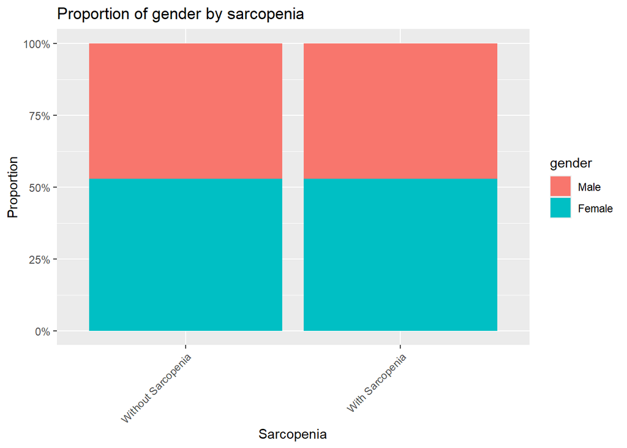

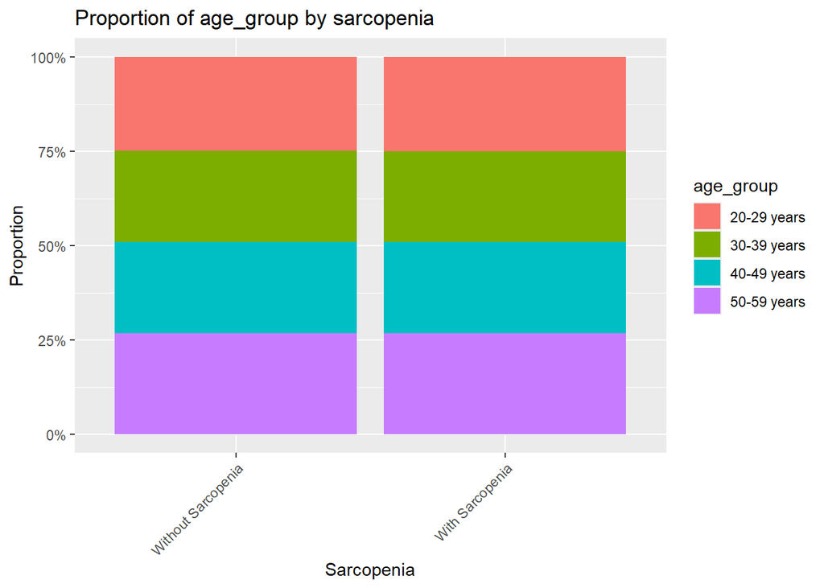

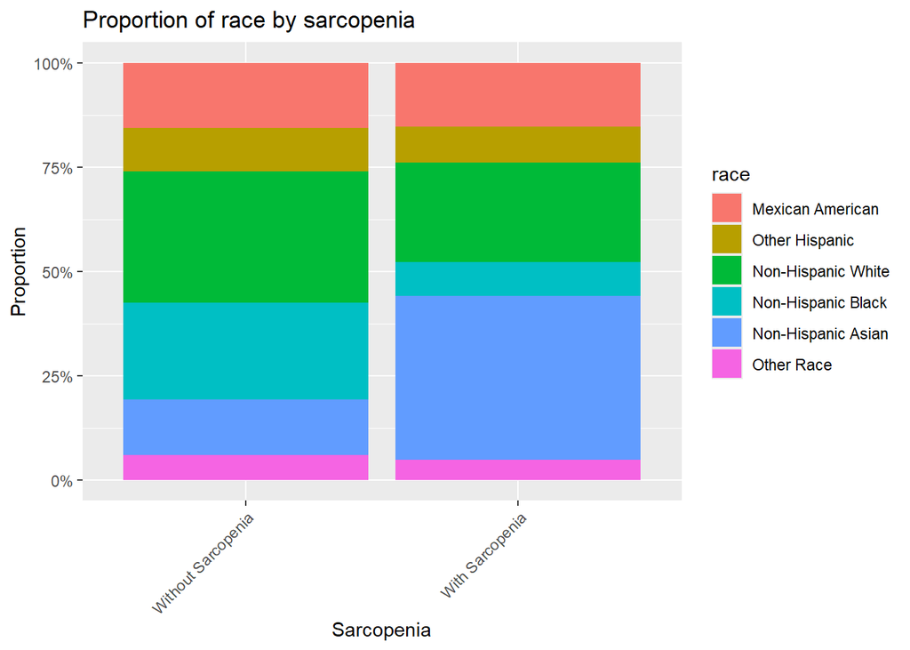

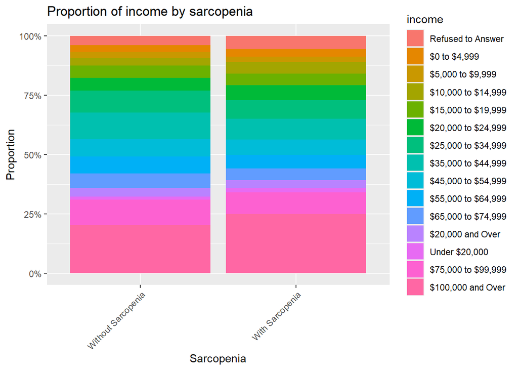

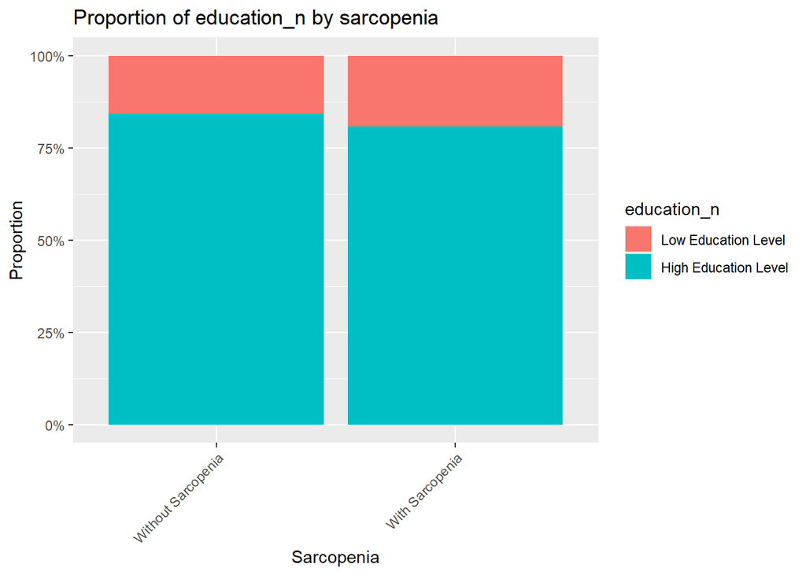

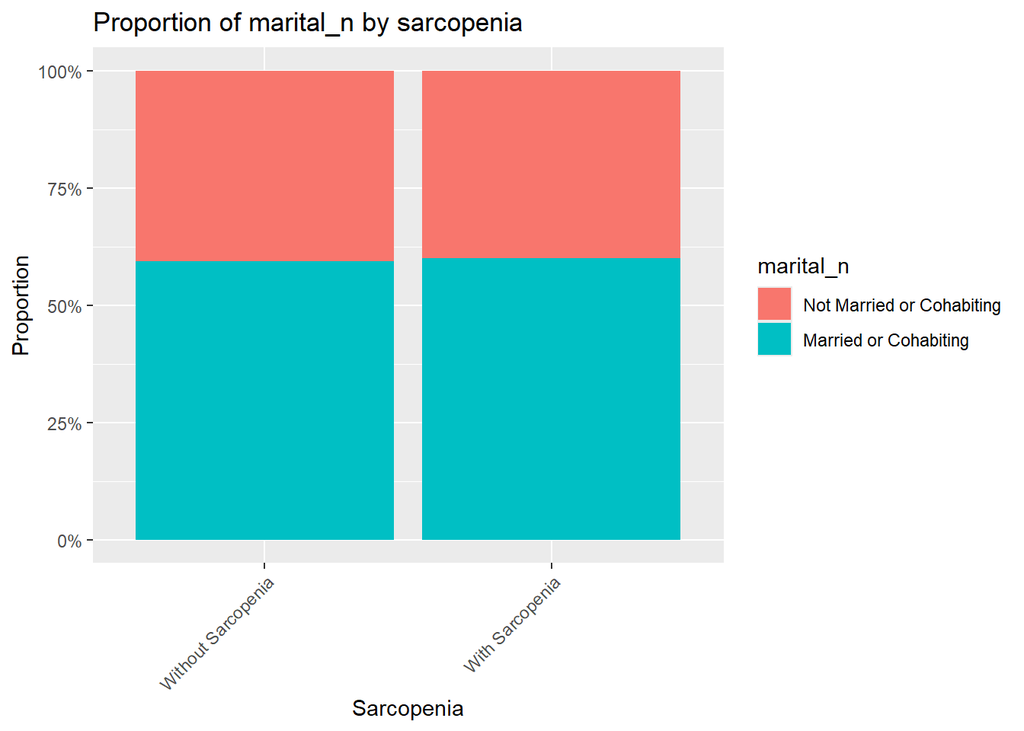

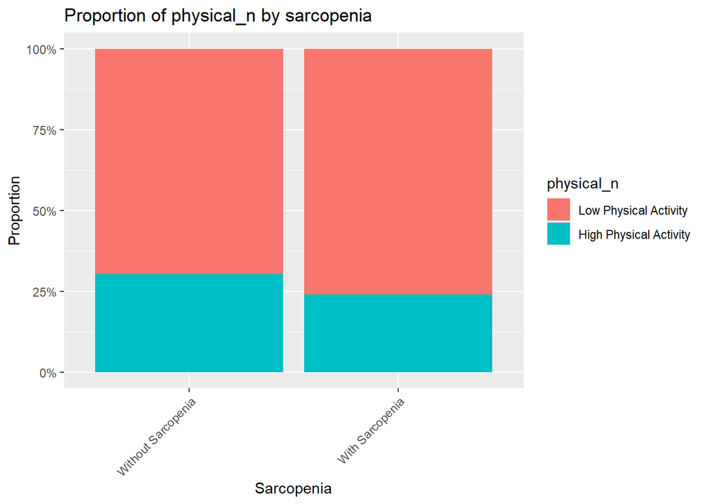

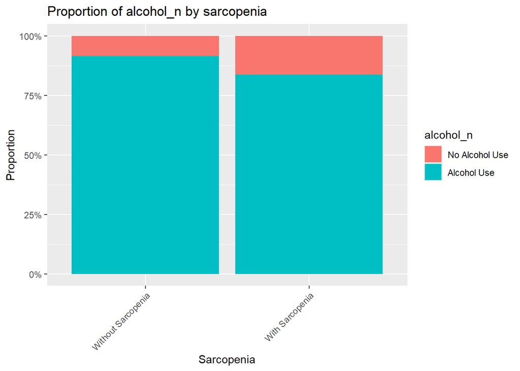

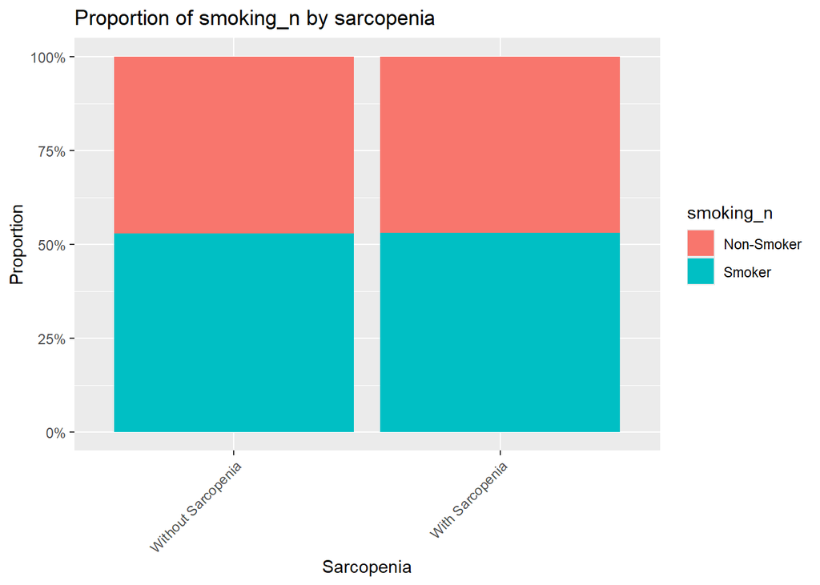

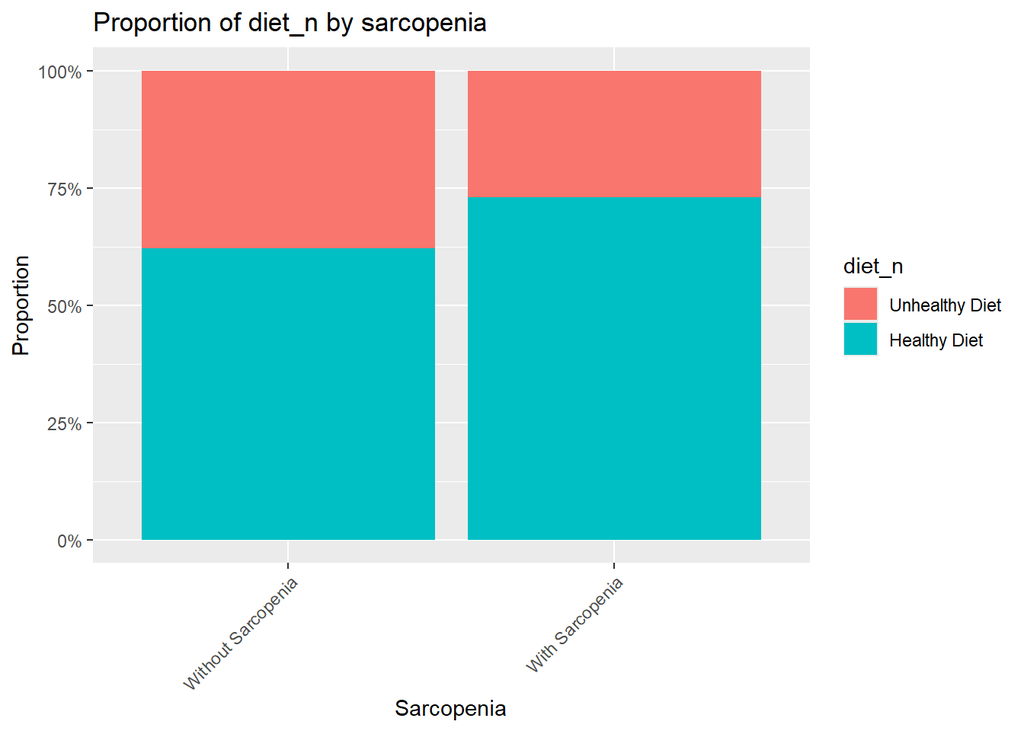

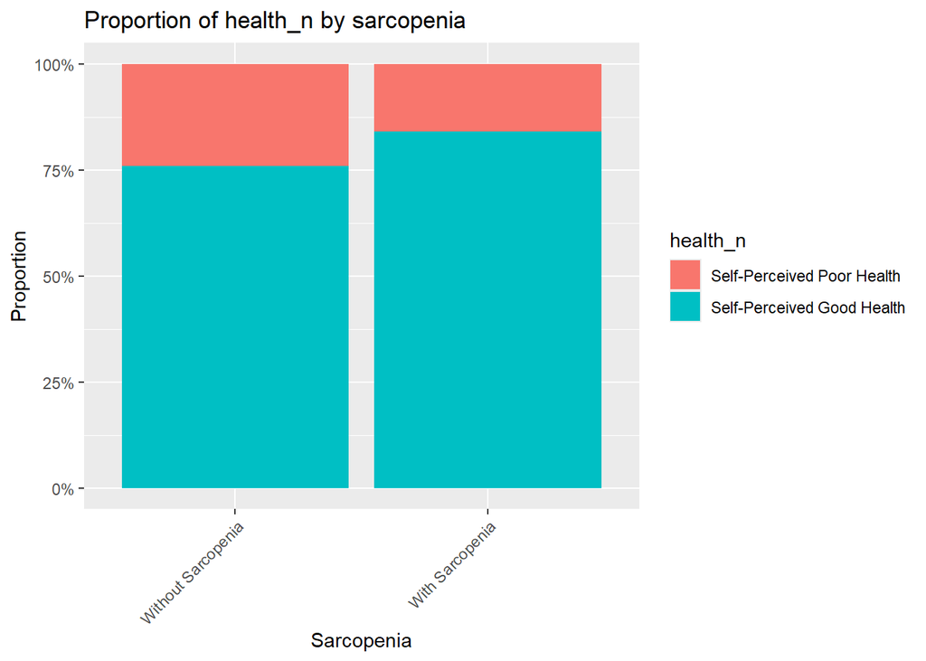

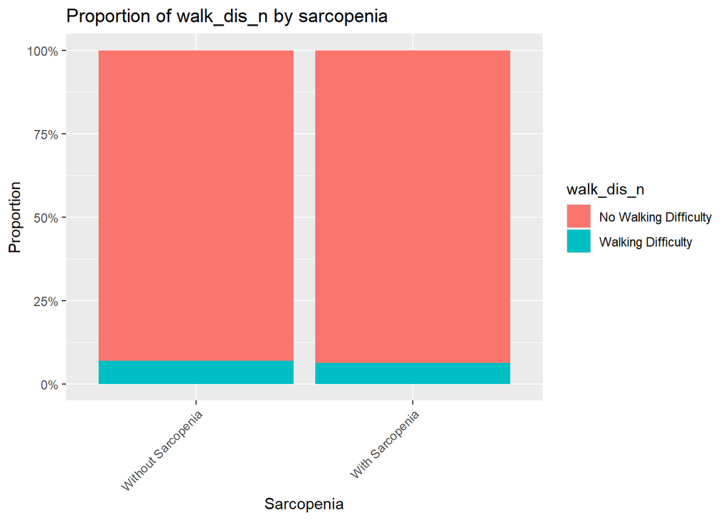

[6 more figures not shown]

```r
# Create bar plots showing proportions for each categorical variable by statin use
categorical_vars <- c("gender", "age_group", "race", "income", "education_n", "marital_n","physical_n", "alcohol_n", "smoking_n", "diet_n", "health_n","walk_dis_n", "HTN_n", "lipid_n", "cardio_n", "diabetes_n", "CKD_n", "statin_use")

for (var in categorical_vars) {
  p <- final_data %>%
    group_by(sarcopenia, .data[[var]]) %>%
    summarise(count = n(), .groups = "drop") %>%
    mutate(proportion = count / sum(count)) %>%
    ggplot(aes_string(x = "sarcopenia", y = "proportion", fill = var)) +
    geom_bar(stat = "identity", position = "fill") +
    labs(title = paste("Proportion of", var, "by sarcopenia"), x = "Sarcopenia", y = "Proportion", fill = var) +
    theme(axis.text.x = element_text(angle = 45, hjust = 1)) +
    scale_y_continuous(labels = scales::percent_format())
  print(p)
}
```

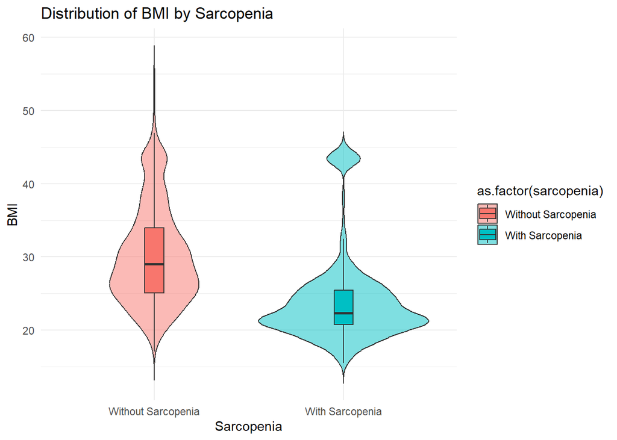

```r
# Create a violin plot for BMI with an overlay of box plot to show density and summary stats
ggplot(final_data, aes(x = as.factor(sarcopenia), y = BMI, fill = as.factor(sarcopenia))) +
  geom_violin(trim = FALSE, alpha = 0.5) +
  geom_boxplot(width = 0.1, position = position_dodge(0.9), outlier.shape = NA) +
  labs(title = "Distribution of BMI by Sarcopenia", x = "Sarcopenia", y = "BMI") +
  theme_minimal()
```

The weighted baseline characteristics of the NHANES study population are presented below, stratified by sarcopenia status. The gender distribution was similar across groups, with around 51% of both sarcopenic and non-sarcopenic participants being female. Age distribution showed slight differences; those with sarcopenia had a higher proportion of individuals in the younger age group (20-29 years) at 31.9%, compared to 27.1% in those without sarcopenia. Additionally, the average BMI was significantly lower in participants with sarcopenia (23.53) than those without (29.67).

Racial composition also varied between the groups. Non-Hispanic White individuals represented the largest proportion in both groups, but they were more common among those without sarcopenia (58.0%) compared to those with sarcopenia (51.3%).

However, among health conditions, hypertension, hyperlipidemia, cardiovascular disease, and diabetes were more prevalent in the non-sarcopenic group. For instance, hypertension was reported by 23.3% of non-sarcopenic participants compared to 14.7% of those with sarcopenia. The prevalence of chronic kidney disease and statin use was relatively low and similar between groups.

```r
# Create weighted Table 1 to show the characteristics stratified by sarcopenia status
survey_design <- svydesign(ids = ~1, data = final_data, weights = ~exam_weight)

table1_weight <- svyCreateTableOne(
  vars = vars,
  strata = "sarcopenia",
  data = survey_design,
  factorVars = factorVars,
  test = FALSE,
)

print(table1_weight, quote = FALSE, noSpaces = TRUE)
```

```
                                           Stratified by sarcopenia
                                            Without Sarcopenia
  n                                         95936368.5
  gender = Female (%)                       48623359.4 (50.7)
  age_group (%)
     20-29 years                            26038892.6 (27.1)
     30-39 years                            23623967.2 (24.6)
     40-49 years                            22362626.6 (23.3)
     50-59 years                            23910882.0 (24.9)
  BMI (mean (SD))                           29.67 (6.55)
  race (%)
     Mexican American                       10431198.6 (10.9)
     Other Hispanic                         8218215.4 (8.6)
     Non-Hispanic White                     55683045.8 (58.0)
     Non-Hispanic Black                     11834799.8 (12.3)
     Non-Hispanic Asian                     4989376.9 (5.2)
     Other Race                             4779732.0 (5.0)
  income (%)
     Refused to Answer                      2535708.5 (2.6)
     $0 to $4,999                           1907564.5 (2.0)
     $5,000 to $9,999                       1573465.1 (1.6)
     $10,000 to $14,999                     2101405.6 (2.2)
     $15,000 to $19,999                     4021171.3 (4.2)
     $20,000 to $24,999                     4002845.0 (4.2)
     $25,000 to $34,999                     6587399.1 (6.9)
     $35,000 to $44,999                     9903190.4 (10.3)
     $45,000 to $54,999                     6968133.1 (7.3)
     $55,000 to $64,999                     6586624.9 (6.9)
     $65,000 to $74,999                     6100258.6 (6.4)
     $20,000 and Over                       3343846.7 (3.5)
     Under $20,000                          663965.4 (0.7)
     $75,000 to $99,999                     14064610.4 (14.7)
     $100,000 and Over                      25576179.9 (26.7)
  education_n = High Education Level (%)    86735177.5 (90.4)
  marital_n = Married or Cohabiting (%)     58347149.9 (60.8)
  physical_n = High Physical Activity (%)   29610390.7 (30.9)
  alcohol_n = Alcohol Use (%)               90179078.9 (94.0)
  smoking_n = Smoker (%)                    45489305.1 (47.4)
  diet_n = Healthy Diet (%)                 62487059.3 (65.1)
  health_n = Self-Perceived Good Health (%) 78783272.2 (82.1)
```

[output cut: 39 more lines]

```
     $100,000 and Over                      5373579.5 (28.1)
  education_n = High Education Level (%)    16769742.4 (87.7)
  marital_n = Married or Cohabiting (%)     10570146.7 (55.3)
  physical_n = High Physical Activity (%)   5031551.6 (26.3)
  alcohol_n = Alcohol Use (%)               16650787.8 (87.1)
  smoking_n = Smoker (%)                    10189068.0 (53.3)
  diet_n = Healthy Diet (%)                 13837427.4 (72.4)
  health_n = Self-Perceived Good Health (%) 16673761.8 (87.2)
  walk_dis_n = Walking Difficulty (%)       927121.4 (4.8)
  HTN_n = Hypertension (%)                  2808061.1 (14.7)
  lipid_n = Hyperlipidemia (%)              4108783.3 (21.5)
  cardio_n = Cardiovascular Disease (%)     1883044.5 (9.9)
  diabetes_n = Diabetes (%)                 778229.9 (4.1)
  CKD_n = Chronic Kidney Disease (%)        220785.7 (1.2)
  statin_use = Statin Use (%)               903008.3 (4.7)
```

2. **Examine the characteristics of individuals under 60 using statins**

The figures of baseline characteristics of the study participants, without applying weights, are presented stratified by statins use below.

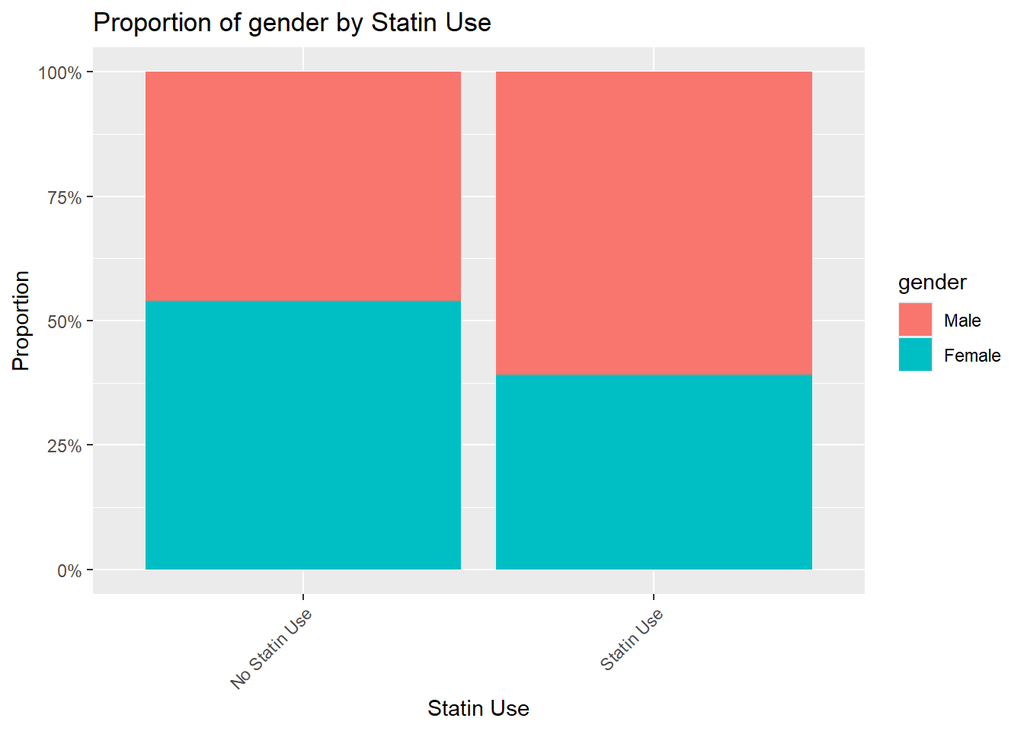

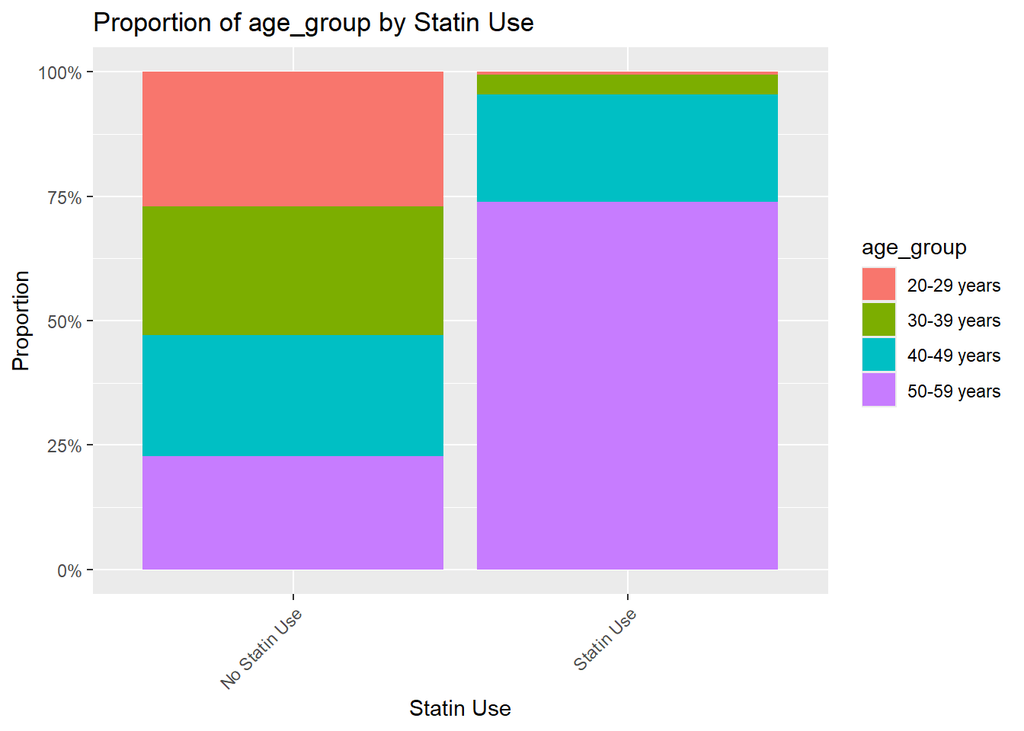

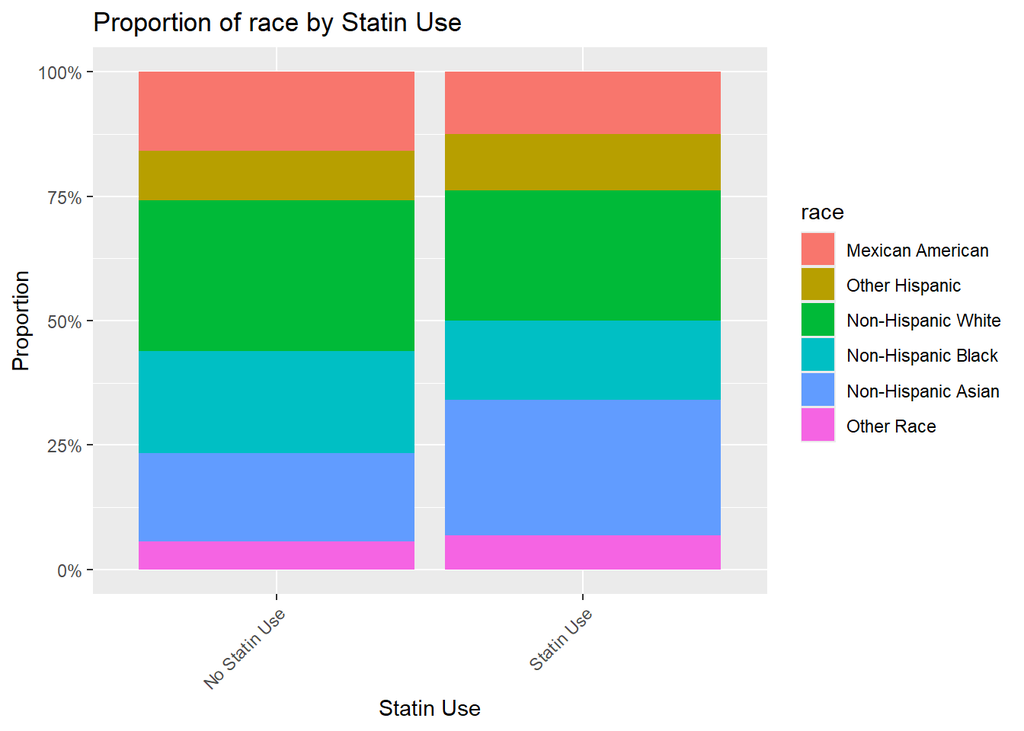

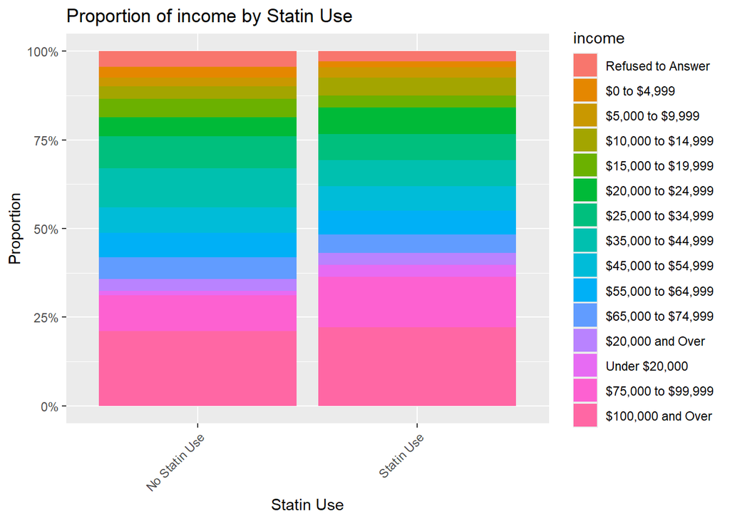

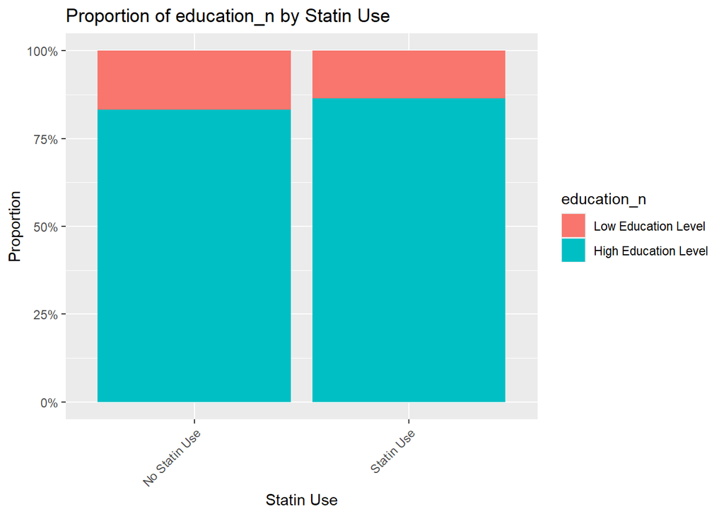

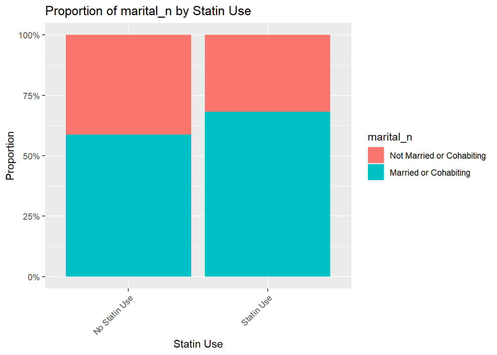

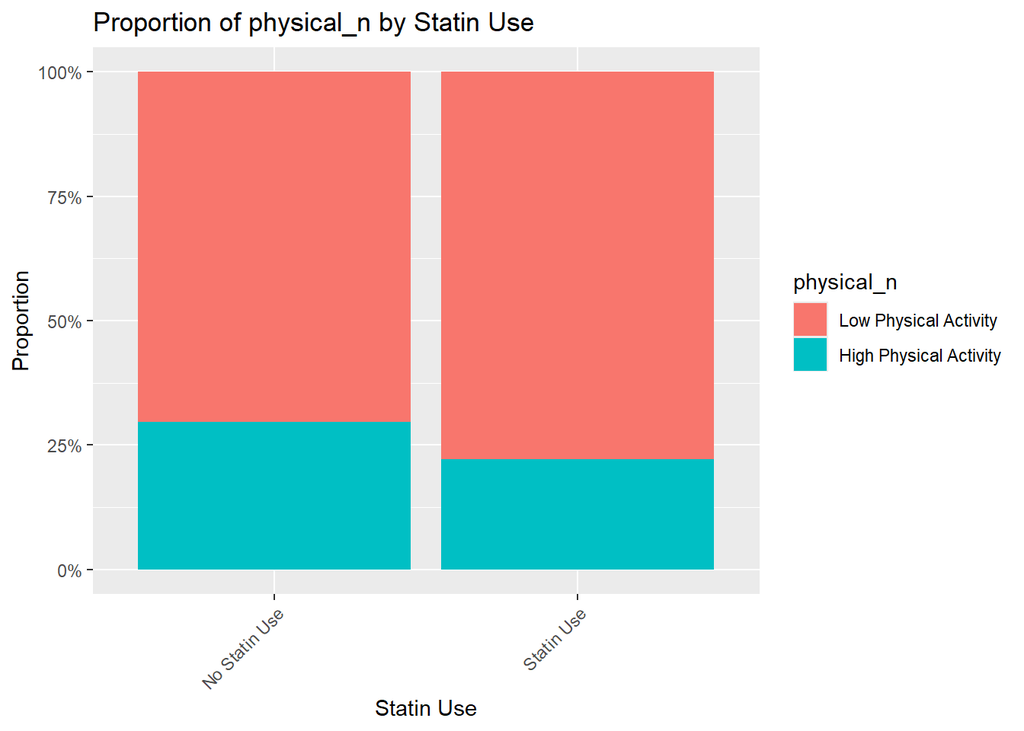

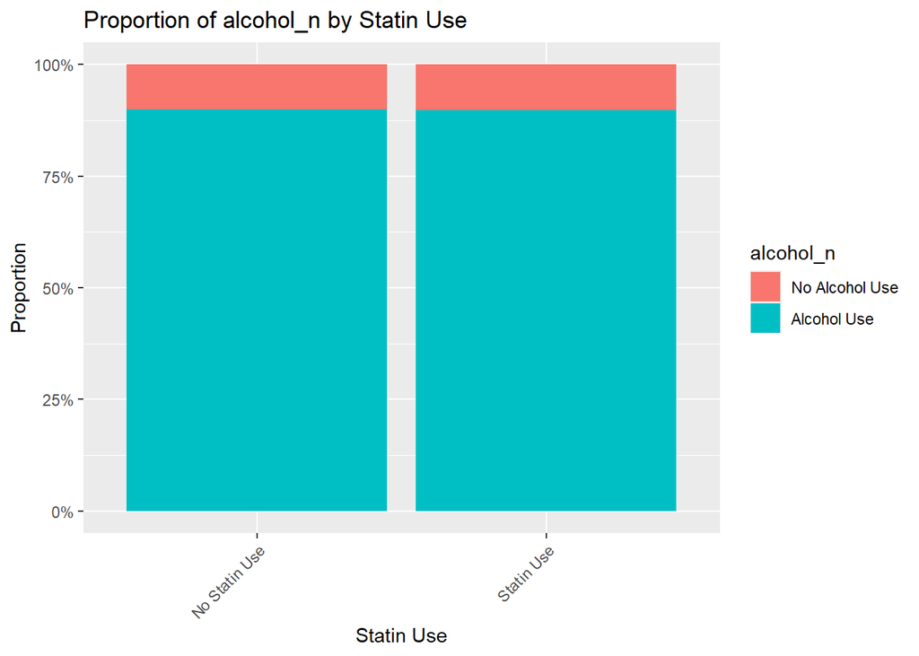

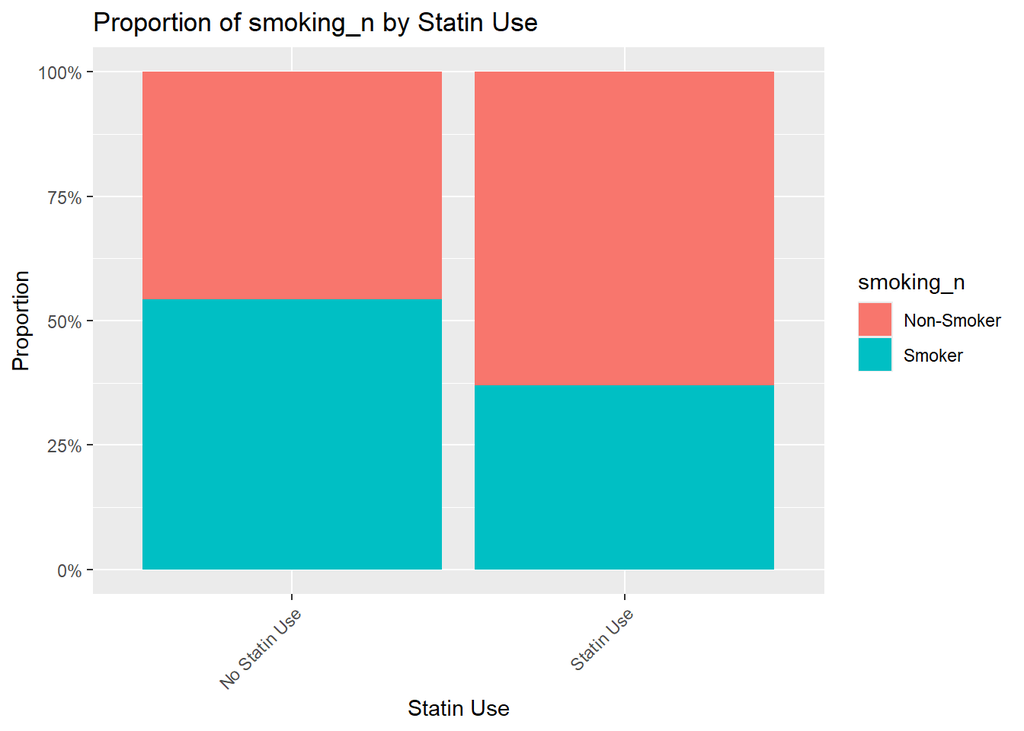

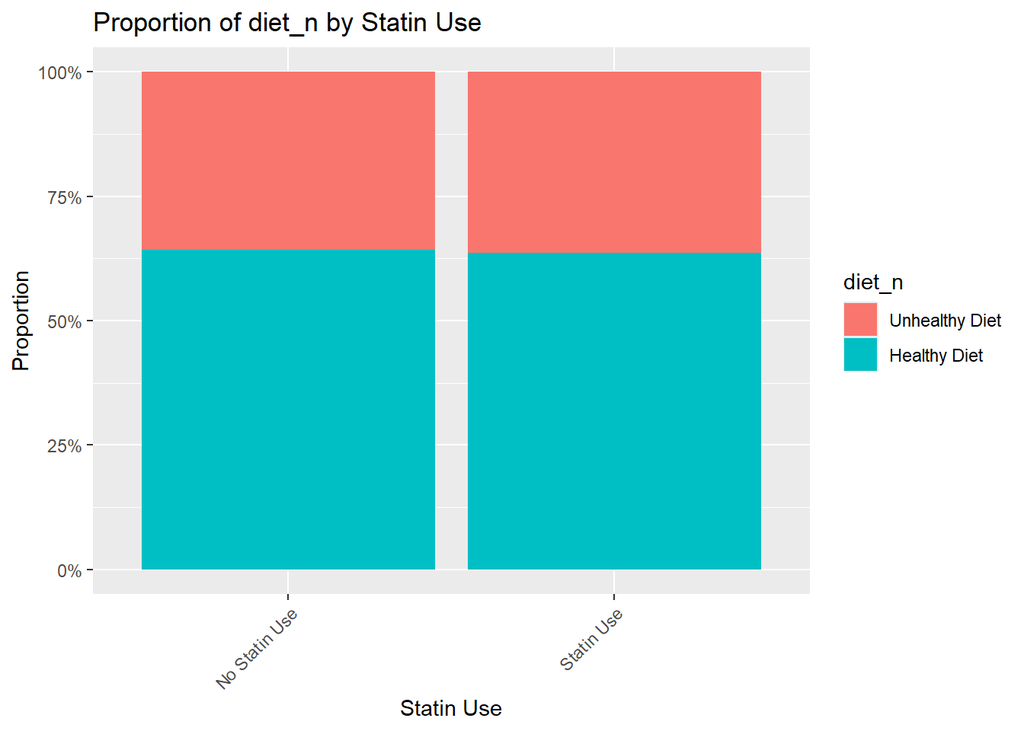

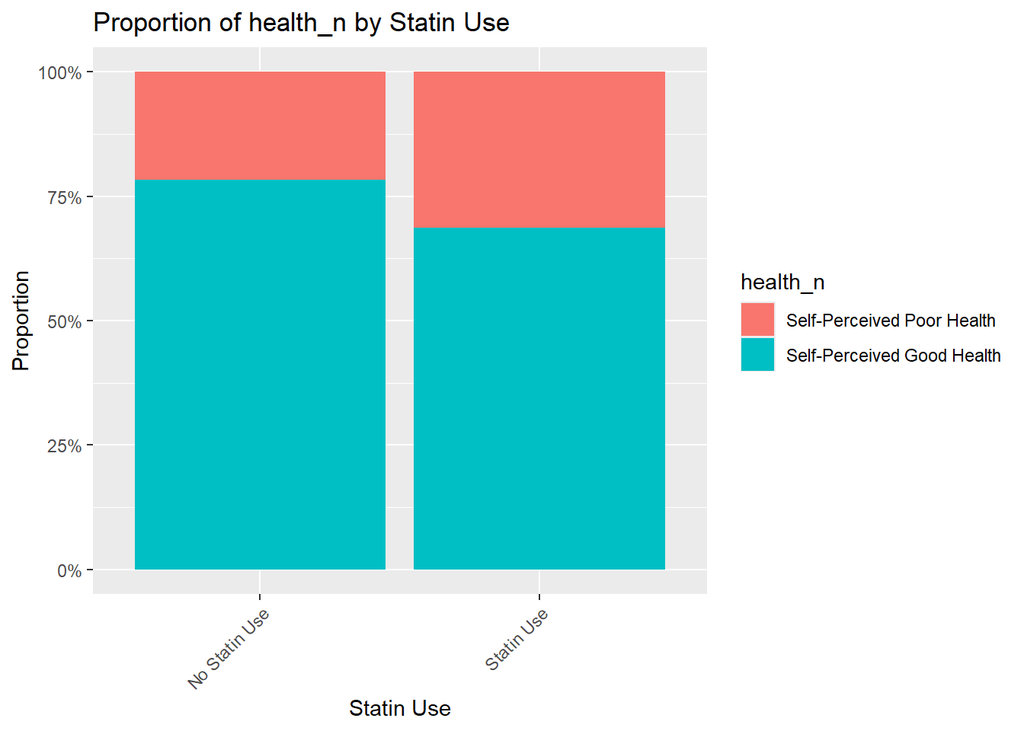

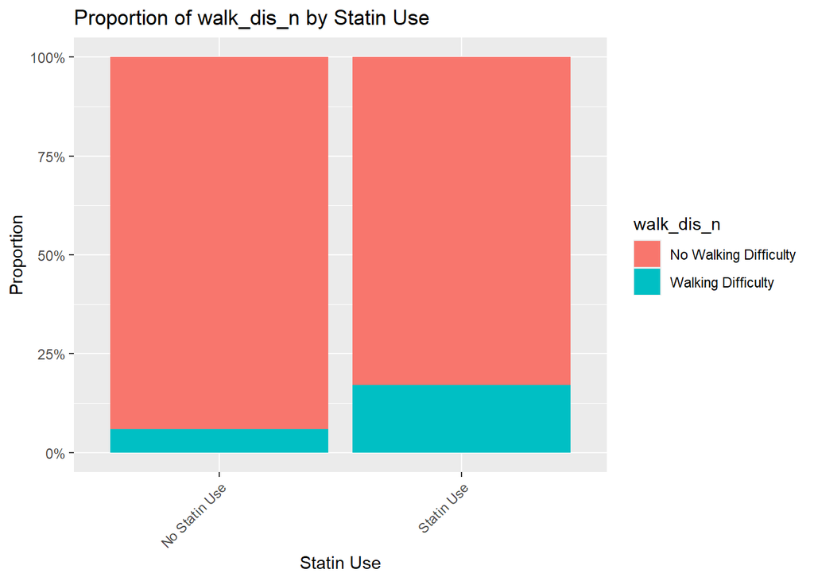

[5 more figures not shown]

```r
#Create plots to show the characteristics stratified by statins use status

# Define a vector of variable names
categorical_vars <- c("gender", "age_group", "race", "income", "education_n", "marital_n","physical_n", "alcohol_n", "smoking_n", "diet_n", "health_n","walk_dis_n", "HTN_n", "lipid_n", "cardio_n", "diabetes_n", "CKD_n")

# Create bar plots showing proportions for each categorical variable by statin use
for (var in categorical_vars) {
  p <- final_data %>%
    group_by(statin_use, .data[[var]]) %>%
    summarise(count = n(), .groups = "drop") %>%
    mutate(proportion = count / sum(count)) %>%
    ggplot(aes_string(x = "statin_use", y = "proportion", fill = var)) +
    geom_bar(stat = "identity", position = "fill") +
    labs(title = paste("Proportion of", var, "by Statin Use"), x = "Statin Use", y = "Proportion", fill = var) +
    theme(axis.text.x = element_text(angle = 45, hjust = 1)) +
    scale_y_continuous(labels = scales::percent_format())
  print(p)
}
```

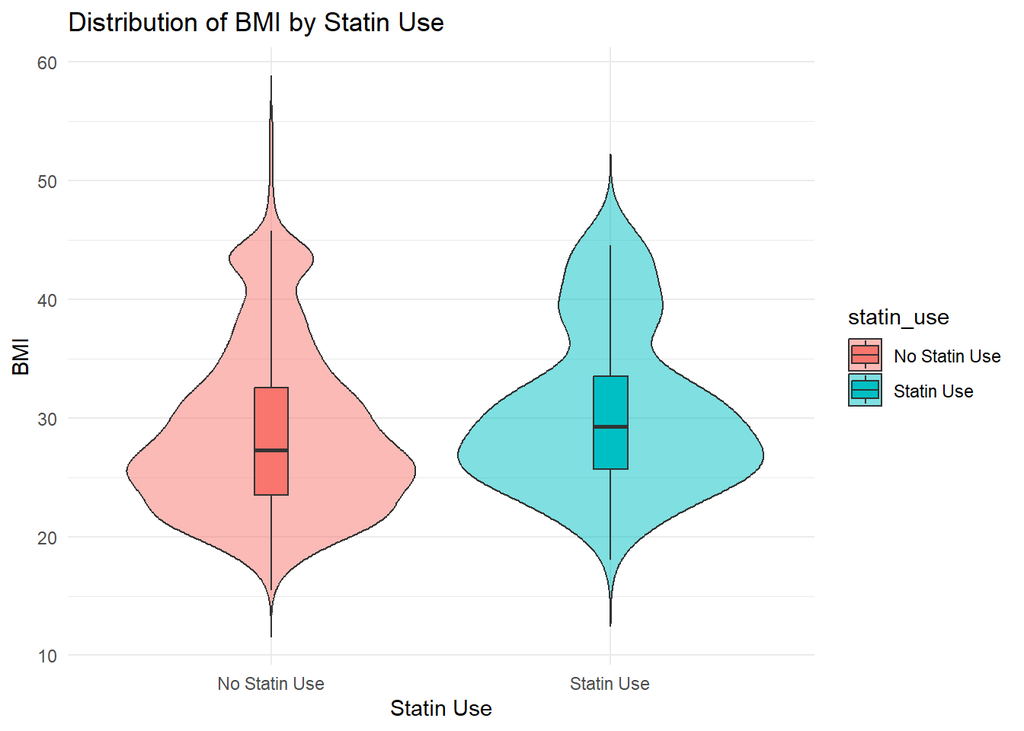

```r
# Create a violin plot for BMI with an overlay of box plot to show density and summary stats
ggplot(final_data, aes(x = statin_use, y = BMI, fill = statin_use)) +
  geom_violin(trim = FALSE, alpha = 0.5) +
  geom_boxplot(width = 0.1, position = position_dodge(0.9), outlier.shape = NA) +
  labs(title = "Distribution of BMI by Statin Use", x = "Statin Use", y = "BMI") +
  theme_minimal()
```

The following table presents the baseline characteristics of participants stratified by statin use, weighted to reflect a distribution more representative of the U.S. population. Among the weighted participants, those not using statins constitute the majority, compared to statin users. Gender distribution shows that a higher percentage of females are not on statins (52.0%) compared to those using statins (34.2%).

In terms of age, statin use is highest in the 50-59 age group (76.0%) among statin users, whereas younger age groups (20-29 and 30-39 years) have lower statin use rates (1.2% and 6.6%, respectively). Racial distribution indicates that non-Hispanic Whites are the largest racial group among both statin users (54.0%) and non-users (57.1%).

```r
# Create weighted Table 2 to show the characteristics stratified by statins use status
table2_weight <- svyCreateTableOne(
  vars = categorical_vars,
  strata = "statin_use",
  data = survey_design,
  factorVars = factorVars,
  test = FALSE,
)

print(table2_weight, quote = FALSE, noSpaces = TRUE)
```

```
                                           Stratified by statin_use
                                            No Statin Use      Statin Use
  n                                         107958766.5        7094502.4
  gender = Female (%)                       56090857.0 (52.0)  2424053.2 (34.2)
  age_group (%)
     20-29 years                            32047061.1 (29.7)  82521.6 (1.2)
     30-39 years                            27614433.1 (25.6)  466978.4 (6.6)
     40-49 years                            25135501.7 (23.3)  1156533.4 (16.3)
     50-59 years                            23161770.7 (21.5)  5388468.9 (76.0)
  race (%)
     Mexican American                       12132884.4 (11.2)  686642.9 (9.7)
     Other Hispanic                         9296374.4 (8.6)    769604.0 (10.8)
     Non-Hispanic White                     61652582.9 (57.1)  3832285.4 (54.0)
     Non-Hispanic Black                     12122271.7 (11.2)  767586.0 (10.8)
     Non-Hispanic Asian                     7473566.2 (6.9)    736762.1 (10.4)
     Other Race                             5281086.9 (4.9)    301622.0 (4.3)
  income (%)
     Refused to Answer                      3607745.1 (3.3)    129848.3 (1.8)
     $0 to $4,999                           2371422.5 (2.2)    72855.6 (1.0)
     $5,000 to $9,999                       1692710.5 (1.6)    143379.3 (2.0)
     $10,000 to $14,999                     2535362.2 (2.3)    312485.3 (4.4)
     $15,000 to $19,999                     4687840.4 (4.3)    265850.3 (3.7)
     $20,000 to $24,999                     4607488.0 (4.3)    539528.7 (7.6)
     $25,000 to $34,999                     7746589.7 (7.2)    392724.1 (5.5)
     $35,000 to $44,999                     11292509.2 (10.5)  510183.3 (7.2)
     $45,000 to $54,999                     7483727.9 (6.9)    407392.6 (5.7)
     $55,000 to $64,999                     7394613.3 (6.8)    275362.3 (3.9)
     $65,000 to $74,999                     6728063.0 (6.2)    291749.6 (4.1)
     $20,000 and Over                       3721545.2 (3.4)    405268.2 (5.7)
     Under $20,000                          819929.9 (0.8)     123805.9 (1.7)
     $75,000 to $99,999                     14306826.6 (13.3)  1236702.4 (17.4)
     $100,000 and Over                      28962393.1 (26.8)  1987366.3 (28.0)
  education_n = High Education Level (%)    97132737.1 (90.0)  6372182.8 (89.8)
  marital_n = Married or Cohabiting (%)     64546098.8 (59.8)  4371197.8 (61.6)
  physical_n = High Physical Activity (%)   33288320.3 (30.8)  1353621.9 (19.1)
  alcohol_n = Alcohol Use (%)               100207538.6 (92.8) 6622328.1 (93.3)
  smoking_n = Smoker (%)                    53043935.7 (49.1)  2634437.5 (37.1)
  diet_n = Healthy Diet (%)                 72037733.8 (66.7)  4286752.9 (60.4)
  health_n = Self-Perceived Good Health (%) 89919301.0 (83.3)  5537733.0 (78.1)
  walk_dis_n = Walking Difficulty (%)       4534125.9 (4.2)    891232.9 (12.6)
  HTN_n = Hypertension (%)                  21240065.4 (19.7)  3968325.3 (55.9)
  lipid_n = Hyperlipidemia (%)              19626050.8 (18.2)  5892620.4 (83.1)
  cardio_n = Cardiovascular Disease (%)     11685265.5 (10.8)  2436333.8 (34.3)
  diabetes_n = Diabetes (%)                 3457868.7 (3.2)    2629347.7 (37.1)
  CKD_n = Chronic Kidney Disease (%)        1609040.4 (1.5)    430569.6 (6.1)
```

3. **Evaluate whether statin use impacts muscle health in younger adults**

```r
#Building logistic regressoin model considering examine weight of NHANES
model <- svyglm(sarcopenia ~ statin_use, design = survey_design, family = quasibinomial())
odds_ratios_with_ci <- exp(cbind(OR = coef(model), confint(model)))
summary(model)
```

```
Call:
svyglm(formula = sarcopenia ~ statin_use, design = survey_design,
    family = quasibinomial())

Survey design:
svydesign(ids = ~1, data = final_data, weights = ~exam_weight)

Coefficients:
                     Estimate Std. Error t value Pr(>|t|)
(Intercept)          -1.59479    0.08198 -19.452   <2e-16 ***
statin_useStatin Use -0.33041    0.31688  -1.043    0.297
---
Signif. codes:  0 '***' 0.001 '**' 0.01 '*' 0.05 '.' 0.1 ' ' 1

(Dispersion parameter for quasibinomial family taken to be 1.000444)

Number of Fisher Scoring iterations: 4
```

```r
odds_ratios_with_ci
```

```
                            OR     2.5 %    97.5 %
(Intercept)          0.2029519 0.1728108 0.2383501
statin_useStatin Use 0.7186264 0.3860346 1.3377661
```

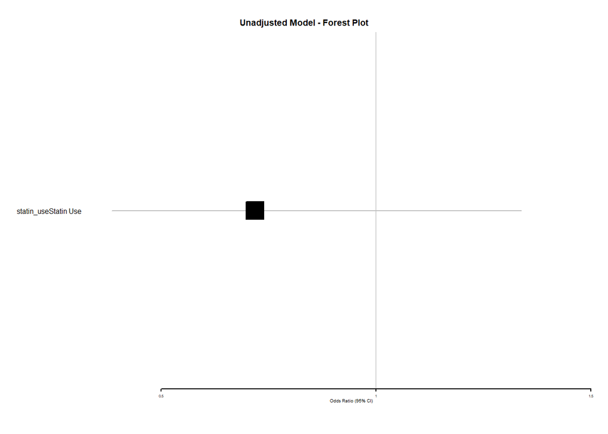

```r
#Forest plot
unadjusted_data <- data.frame(
  Variable = rownames(odds_ratios_with_ci),
  OR = odds_ratios_with_ci[, "OR"],
  CI_low = odds_ratios_with_ci[, "2.5 %"],
  CI_high = odds_ratios_with_ci[, "97.5 %"]
) %>%
  filter(Variable != "(Intercept)")

forestplot(
  labeltext = unadjusted_data$Variable,
  mean = unadjusted_data$OR,
  lower = unadjusted_data$CI_low,
  upper = unadjusted_data$CI_high,
  zero = 1,
  title = "Unadjusted Model - Forest Plot",
  xlab = "Odds Ratio (95% CI)",
  boxsize = 0.05,
  txt_gp = fpTxtGp(label = gpar(fontsize = 6))
)
```

```r
#Building adjusted logistic regressoin models considering examine weight of NHANES
adjustment_vars <- setdiff(names(final_data), c("sarcopenia", "statin_use", "id", "exam_weight"))
formula <- as.formula(paste("sarcopenia ~ statin_use +", paste(adjustment_vars, collapse = " + ")))
model2 <- svyglm(formula, design = survey_design, family = quasibinomial())
odds_ratios_with_ci2 <- exp(cbind(OR = coef(model2), confint(model2)))
summary(model2)
```

```
Call:
svyglm(formula = formula, design = survey_design, family = quasibinomial())

Survey design:
svydesign(ids = ~1, data = final_data, weights = ~exam_weight)

Coefficients:
                                   Estimate Std. Error t value Pr(>|t|)
(Intercept)                         8.57436    1.28048   6.696 2.70e-11 ***
statin_useStatin Use               -0.15275    0.40309  -0.379 0.704762
genderFemale                       -0.30215    0.17712  -1.706 0.088163 .
raceOther Hispanic                 -0.74371    0.29530  -2.518 0.011857 *
raceNon-Hispanic White             -1.07939    0.26143  -4.129 3.78e-05 ***
raceNon-Hispanic Black             -1.88741    0.29254  -6.452 1.35e-10 ***
raceNon-Hispanic Asian             -0.06492    0.24136  -0.269 0.787986
raceOther Race                     -0.92028    0.36148  -2.546 0.010968 *
age_group30-39 years                0.16162    0.24009   0.673 0.500931
age_group40-49 years                0.20661    0.24913   0.829 0.407013
age_group50-59 years               -0.01561    0.29136  -0.054 0.957268
anxious_nHistory of Anxiety        -0.44517    0.20953  -2.125 0.033729 *
depression_nHistory of Depression   0.30664    0.18578   1.651 0.098969 .
fractured_nHistory of Fracture      0.03825    0.48677   0.079 0.937369
physical_nHigh Physical Activity    0.02785    0.20012   0.139 0.889325
BMI                                -0.26464    0.04244  -6.235 5.38e-10 ***
income$0 to $4,999                 -0.76601    0.63008  -1.216 0.224219
income$5,000 to $9,999             -1.47500    0.71502  -2.063 0.039239 *
income$10,000 to $14,999           -0.69055    0.66469  -1.039 0.298968
income$15,000 to $19,999           -1.36052    0.56476  -2.409 0.016076 *
income$20,000 to $24,999           -1.03479    0.56472  -1.832 0.067026 .
income$25,000 to $34,999           -1.13685    0.56730  -2.004 0.045196 *
income$35,000 to $44,999           -1.14720    0.52999  -2.165 0.030526 *
income$45,000 to $54,999           -1.79730    0.56893  -3.159 0.001604 **
income$55,000 to $64,999           -1.23324    0.54874  -2.247 0.024712 *
income$65,000 to $74,999           -1.57380    0.60493  -2.602 0.009340 **
income$20,000 and Over             -1.05011    0.83251  -1.261 0.207306
incomeUnder $20,000                -0.76958    0.67374  -1.142 0.253477
income$75,000 to $99,999           -1.94619    0.53261  -3.654 0.000264 ***
income$100,000 and Over            -1.24142    0.51392  -2.416 0.015791 *
alcohol_nAlcohol Use               -0.82955    0.33784  -2.455 0.014148 *
HTN_nHypertension                   0.01562    0.25499   0.061 0.951172
lipid_nHyperlipidemia               0.22875    0.25636   0.892 0.372334
cardio_nCardiovascular Disease     -0.27848    0.26810  -1.039 0.299045
diet_nHealthy Diet                 -0.16360    0.20455  -0.800 0.423909
education_nHigh Education Level    -0.22757    0.21502  -1.058 0.290002
marital_nMarried or Cohabiting     -0.17895    0.17841  -1.003 0.315963
diabetes_nDiabetes                  0.49535    0.38449   1.288 0.197766
walk_dis_nWalking Difficulty        0.81360    0.34997   2.325 0.020174 *
health_nSelf-Perceived Good Health  0.16981    0.26128   0.650 0.515824
CKD_nChronic Kidney Disease         0.02720    0.69514   0.039 0.968790
smoking_nSmoker                     0.06612    0.19449   0.340 0.733903
---
Signif. codes:  0 '***' 0.001 '**' 0.01 '*' 0.05 '.' 0.1 ' ' 1

(Dispersion parameter for quasibinomial family taken to be 2.019638)

Number of Fisher Scoring iterations: 6
```

```r
odds_ratios_with_ci2
```

```
                                             OR        2.5 %       97.5 %
(Intercept)                        5294.1457880 429.78508281 6.521394e+04
statin_useStatin Use                  0.8583453   0.38937390 1.892157e+00
genderFemale                          0.7392298   0.52231857 1.046221e+00
raceOther Hispanic                    0.4753484   0.26638623 8.482275e-01
raceNon-Hispanic White                0.3398043   0.20350482 5.673917e-01
raceNon-Hispanic Black                0.1514632   0.08534156 2.688151e-01
raceNon-Hispanic Asian                0.9371456   0.58377621 1.504415e+00
raceOther Race                        0.3984080   0.19609596 8.094452e-01
age_group30-39 years                  1.1754081   0.73402203 1.882211e+00
age_group40-49 years                  1.2295043   0.75431274 2.004050e+00
age_group50-59 years                  0.9845076   0.55600160 1.743260e+00
anxious_nHistory of Anxiety           0.6407169   0.42483270 9.663053e-01
depression_nHistory of Depression     1.3588516   0.94395295 1.956112e+00
fractured_nHistory of Fracture        1.0389944   0.39998828 2.698853e+00
physical_nHigh Physical Activity      1.0282425   0.69448453 1.522399e+00
BMI                                   0.7674805   0.70618838 8.340924e-01
income$0 to $4,999                    0.4648657   0.13511606 1.599366e+00
income$5,000 to $9,999                0.2287778   0.05629346 9.297582e-01
income$10,000 to $14,999              0.5013017   0.13614438 1.845860e+00
income$15,000 to $19,999              0.2565283   0.08475225 7.764605e-01
income$20,000 to $24,999              0.3553006   0.11739322 1.075348e+00
income$25,000 to $34,999              0.3208278   0.10546786 9.759418e-01
income$35,000 to $44,999              0.3175248   0.11230676 8.977373e-01
income$45,000 to $54,999              0.1657456   0.05431285 5.058028e-01
income$55,000 to $64,999              0.2913477   0.09932725 8.545839e-01
income$65,000 to $74,999              0.2072553   0.06328612 6.787392e-01
income$20,000 and Over                0.3498996   0.06837875 1.790465e+00
incomeUnder $20,000                   0.4632095   0.12358707 1.736129e+00
income$75,000 to $99,999              0.1428172   0.05025460 4.058687e-01
income$100,000 and Over               0.2889738   0.10547940 7.916796e-01
alcohol_nAlcohol Use                  0.4362465   0.22490659 8.461780e-01
HTN_nHypertension                     1.0157384   0.61605314 1.674733e+00
lipid_nHyperlipidemia                 1.2570243   0.76034502 2.078149e+00
cardio_nCardiovascular Disease        0.7569318   0.44743028 1.280525e+00
diet_nHealthy Diet                    0.8490816   0.56851391 1.268112e+00
education_nHigh Education Level       0.7964678   0.52244946 1.214205e+00
marital_nMarried or Cohabiting        0.8361494   0.58930197 1.186396e+00
diabetes_nDiabetes                    1.6410689   0.77209415 3.488056e+00
walk_dis_nWalking Difficulty          2.2560142   1.13575532 4.481247e+00
health_nSelf-Perceived Good Health    1.1850747   0.70994045 1.978197e+00
CKD_nChronic Kidney Disease           1.0275746   0.26289687 4.016440e+00
smoking_nSmoker                       1.0683574   0.72958739 1.564429e+00
```

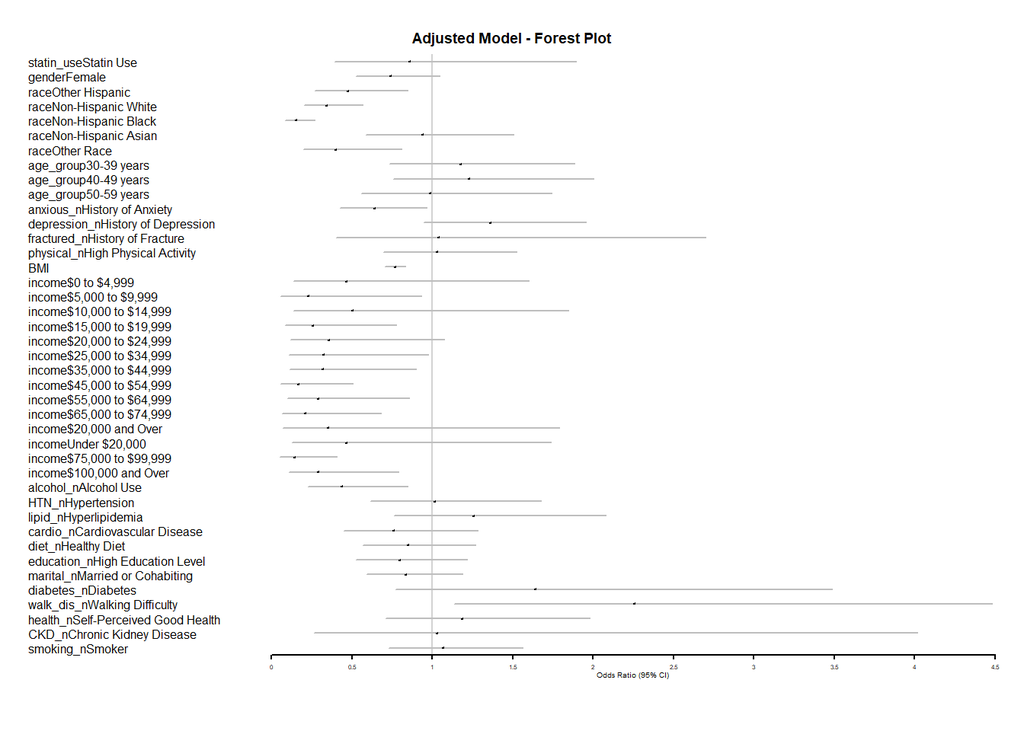

```r
#Forest plot
adjusted_data <- data.frame(
  Variable = rownames(odds_ratios_with_ci2),
  OR = odds_ratios_with_ci2[, "OR"],
  CI_low = odds_ratios_with_ci2[, "2.5 %"],
  CI_high = odds_ratios_with_ci2[, "97.5 %"]
) %>%
  filter(Variable != "(Intercept)")

forestplot(
  labeltext = adjusted_data$Variable,
  mean = adjusted_data$OR,
  lower = adjusted_data$CI_low,
  upper = adjusted_data$CI_high,
  zero = 1,
  title = "Adjusted Model - Forest Plot",
  xlab = "Odds Ratio (95% CI)",
  boxsize = 0.05,
  txt_gp = fpTxtGp(label = gpar(fontsize = 6))
)
```

## 5 Conclusion

To the best of my knowledge, this is the first cross-sectional study to explore the characteristics of individuals under 60 with sarcopenia, examine the characteristics of individuals under 60 using statins, and evaluate whether statin use impacts muscle health in younger adults. Overall, I found that younger individuals with sarcopenia were more likely to be in the youngest age group (20-29 years), engage less frequently in high physical activity, smoke, and have fewer comorbidities. Comparing statin users to non-users, I observed that statin users were more likely to be in the older age group (50-59 years), have a higher prevalence of walking difficulties, and experience more comorbidities. Logistic regression analysis indicated a non-statistically significant reduction in the risk of sarcopenia among statin users, even after adjusting for numerous potential confounders.

Interestingly, statin use in this sample was consistently associated with a lower likelihood of sarcopenia. Although this result was unexpected, it aligns with a recent cross-sectional study focusing on heart failure patients aged 18 and older (11), which found that statin use was inversely associated with sarcopenia, with an OR of 0.03 (95% CI 0.01-0.30). A possible explanation for this potential protective effect of statins may be related to their circulatory benefits, which could positively impact neuromuscular function and help preserve muscle strength, quantity, and quality.

However, there are some important limitations to consider. First, this was a cross-sectional study, which does not allow for causal inference. Second, our sample size of around 2,000 participants is relatively small and may lack sufficient statistical power. Third, we defined sarcopenia as having an appendicular muscle mass in the lowest 20% within each age group and gender. While this algorithm is widely used in older populations, its validity has not been established in younger populations, as in our study. Future studies with longitudinal follow-up are needed to assess the association between statin use and sarcopenia risk to better inform clinical practice in younger populations.

In conclusion, although the findings were contrary to expectations, this study suggests that patients taking statins were less likely to be sarcopenic. Further studies are warranted to investigate the mechanisms and causal relationships involved in this association.

## 6 References

1. Arnett DK, Blumenthal RS, Albert MA, et al. 2019 ACC/AHA Guideline on the Primary Prevention of Cardiovascular Disease: A Report of the American College of Cardiology/American Heart Association Task Force on Clinical Practice Guidelines. Circulation. 2019;140(11):e596-e646.
2. Jacobs JA, Addo DK, Zheutlin AR, et al. Prevalence of Statin Use for Primary Prevention of Atherosclerotic Cardiovascular Disease by Race, Ethnicity, and 10-Year Disease Risk in the US: National Health and Nutrition Examination Surveys, 2013 to March 2020. *JAMA Cardiol*. 2023;8(5):443-452.
3. Bielecka-Dabrowa A, Fabis J, Mikhailidis DP, et al. Prosarcopenic Effects of Statins May Limit Their Effectiveness in Patients with Heart Failure. Trends Pharmacol Sci. 2018;39(4):331-353.
4. Crisan E, Patil VK. Neuromuscular Complications of Statin Therapy. Curr Neurol Neurosci Rep. 2020;20(10):47.
5. Schwendner KI, Mikesky AE, Holt WS, Jr., Peacock M, Burr DB. Differences in muscle endurance and recovery between fallers and nonfallers, and between young and older women. J Gerontol A Biol Sci Med Sci. May 1997;52(3):M155-60.
6. Campins L, Camps M, Riera A, Pleguezuelos E, Yebenes JC, Serra-Prat M. Oral Drugs Related with Muscle Wasting and Sarcopenia. A Review. *Pharmacology*. 2017;99(1-2):1-8.
7. Liu LY, Aimaiti X, Zheng YY, et al. Epidemic trends of dyslipidemia in young adults: a real-world study including more than 20,000 samples. *Lipids Health Dis*. 2023;22(1):108.
8. Stone NJ, Smith SC Jr, Orringer CE, et al. Managing Atherosclerotic Cardiovascular Risk in Young Adults: JACC State-of-the-Art Review. *J Am Coll Cardiol*. 2022;79(8):819-836.
9. Zhang X, Chen Z, Fang A, et al. Trends in prevalence, risk factor control and medications in atherosclerotic cardiovascular disease among US Adults, 1999-2018. *Am J Prev Cardiol*. 2024;17:100634.
10. Jung HN, Jung CH, Hwang YC. Sarcopenia in youth. *Metabolism*. 2023;144:155557.
11. Valdiviesso R, Sousa-Santos AR, Azevedo LF, et al. Statins are associated with reduced likelihood of sarcopenia in a sample of heart failure outpatients: a cross-sectional study. *BMC Cardiovasc Disord*. 2022;22(1):356.